# DAP-seq SPL1 TF peak annotation overview

Teitur Ahlgren Kalman

2026-06-04

# 1 Description

Overview of annotation features intersecting DAP-seq SPL1 TF consensus peaks. The analysis classifies each overlap by feature type, extracts gene IDs, and summarizes both total peak feature overlaps and unique gene feature overlaps. It also summarizes selected promoter region overlaps, defined here as peaks overlapping the 5 kb upstream TSS region or 5’ UTR. I also explore the count of peak overlap in the 5-10kb region upstream and first intron.

I also test promoter peak overlap against the DE gene set in three ways: whether SPL1 peaks overlap positive DE genes more often than negative DE genes, whether SPL1 peaks overlap negative DE genes more often than positive DE genes, and whether SPL1 peaks overlap DE genes as a group more than expected from the expressed gene background.

# 2 Libraries and functions

```r
suppressPackageStartupMessages({
  library(dplyr)
  library(readr)
  library(here)
  library(stringr)
  library(ggplot2)
  library(openxlsx)
})

remove_redundant_annotation_hits <- function(annotation_table) {
  annotation_table %>%
    mutate(
      is_intergenic = annotation == ".",
      is_whole_gene = str_detect(
        annotation,
        "^ID=[^;.]+_[Gg][0-9]+$"
      ),
      is_parent_mrna = str_detect(
        annotation,
        "^ID=[^;]+\\.mRNA\\.[^.;]+;Parent=[^;]+$"
      )
    ) %>%
    filter(
      is_intergenic | (!is_whole_gene & !is_parent_mrna)
    ) %>%
    select(-is_intergenic, -is_whole_gene, -is_parent_mrna)
}

add_annotation_features <- function(annotation_table) {
  annotation_table %>%
    mutate(
      peak_id = paste(peak_chr, peak_start, peak_end, sep = ":"),
      feature_type = case_when(
        annotation == "." ~ "intergenic",
        str_detect(annotation, regex("\\.promoter5kb", ignore_case = TRUE)) ~ "upstream TSS 5kb",
        str_detect(annotation, regex("\\.upstream_TSS_5to10kb", ignore_case = TRUE)) ~ "upstream TSS 5-10kb",
        str_detect(annotation, regex("\\.downstream_promoter5kb", ignore_case = TRUE)) ~ "downstream TES 5kb",
        str_detect(annotation, regex("\\.downstream_TES_5to10kb", ignore_case = TRUE)) ~ "downstream TES 5-10kb",
        str_detect(annotation, regex("cds", ignore_case = TRUE)) ~ "cds",
        str_detect(annotation, regex("\\.intron\\.1(;|$)", ignore_case = TRUE)) ~ "first intron",
        str_detect(annotation, regex("intron", ignore_case = TRUE)) ~ "other intron",
        str_detect(annotation, regex("five_prime_UTR", ignore_case = TRUE)) ~ "5' UTR",
        str_detect(annotation, regex("three_prime_UTR", ignore_case = TRUE)) ~ "3' UTR",
        TRUE ~ NA_character_
      ),
      gene_id = case_when(
        annotation == "." ~ NA_character_,
        TRUE ~ str_match(annotation, "^ID=([^.;]+_[Gg][0-9]+)")[, 2]
      )
    ) %>%
    filter(!is.na(feature_type)) %>%
    select(
      peak_id,
      peak_chr,
      peak_start,
      peak_end,
      feature_chr,
      feature_start,
      feature_end,
      annotation,
      feature_type,
      gene_id,
      score,
      strand,
      overlap_bp
    )
}

make_feature_count_table <- function(annotation_table) {
  annotation_table %>%
    count(feature_type, name = "count") %>%
    mutate(
      feature_type = factor(
        feature_type,
        levels = c(
          "upstream TSS 5-10kb",
          "upstream TSS 5kb",
          "5' UTR",
          "cds",
          "first intron",
          "other intron",
          "3' UTR",
          "downstream TES 5kb",
          "downstream TES 5-10kb",
          "intergenic"
        )
      )
    ) %>%
    arrange(feature_type)
}

make_unique_feature_count_table <- function(annotation_table) {
  annotation_table %>%
    filter(feature_type != "intergenic") %>%
    filter(!is.na(gene_id)) %>%
    distinct(gene_id, feature_type) %>%
    count(feature_type, name = "count") %>%
    mutate(
      feature_type = factor(
        feature_type,
        levels = c(
          "upstream TSS 5-10kb",
          "upstream TSS 5kb",
          "5' UTR",
          "cds",
          "first intron",
          "other intron",
          "3' UTR",
          "downstream TES 5kb",
          "downstream TES 5-10kb"
        )
      )
    ) %>%
    arrange(feature_type)
}

make_feature_count_plot <- function(feature_count_table, plot_title) {
  ggplot(feature_count_table, aes(x = feature_type, y = count)) +
    geom_col() +
    geom_text(
      aes(label = count),
      vjust = -0.3,
      size = 4
    ) +
    scale_y_continuous(
      expand = expansion(mult = c(0, 0.15))
    ) +
    labs(
      title = plot_title,
      x = NULL,
      y = "Count"
    ) +
    theme_bw() +
    theme(
      axis.text.x = element_text(angle = 45, hjust = 1)
    )
}

make_selected_feature_union_table <- function(annotation_table) {
  feature_combinations <- list(
    "upstream TSS 5-10kb + upstream TSS 5kb\n+ 5' UTR + first intron" =
      c("upstream TSS 5-10kb", "upstream TSS 5kb", "5' UTR", "first intron"),

    "upstream TSS 5-10kb + upstream TSS 5kb\n+ 5' UTR" =
      c("upstream TSS 5-10kb", "upstream TSS 5kb", "5' UTR"),

    "upstream TSS 5kb + 5' UTR" =
      c("upstream TSS 5kb", "5' UTR"),

    "5' UTR + first intron" =
      c("5' UTR", "first intron")
  )

  gene_feature_table <- annotation_table %>%
    filter(feature_type != "intergenic") %>%
    filter(!is.na(gene_id)) %>%
    distinct(gene_id, feature_type)

  bind_rows(
    lapply(names(feature_combinations), function(combination_name) {
      selected_features <- feature_combinations[[combination_name]]

      gene_feature_table %>%
        filter(feature_type %in% selected_features) %>%
        summarise(
          feature_combination = combination_name,
          gene_count = n_distinct(gene_id),
          .groups = "drop"
        )
    })
  ) %>%
    mutate(
      feature_combination = factor(
        feature_combination,
        levels = names(feature_combinations)
      )
    )
}

make_selected_feature_union_plot <- function(feature_union_table, plot_title) {
  ggplot(feature_union_table, aes(x = feature_combination, y = gene_count)) +
    geom_col() +
    geom_text(
      aes(label = gene_count),
      vjust = -0.3,
      size = 4
    ) +
    scale_y_continuous(
      expand = expansion(mult = c(0, 0.15))
    ) +
    labs(
      title = plot_title,
      x = NULL,
      y = "Unique genes"
    ) +
    theme_bw() +
    theme(
      axis.text.x = element_text(angle = 45, hjust = 1)
    )
}
```

# 3 Data

```r
annotation_intersect_file <- here("data/SPL1.consensus_peaks.annotation_intersect.tsv")

de_file <- here("data/TableS6_PsSPL1_DE_with_v2_ids.xlsx")

gene_universe_file <- here("data/genes_expressed_in_lateral_organs_expAbove0_with_v2_ids.xlsx")

tf_name <- str_remove(
  basename(annotation_intersect_file),
  "\\.consensus_peaks\\.annotation_intersect\\.tsv$"
)

annotation_intersect <- read_tsv(
  annotation_intersect_file,
  col_names = c(
    "peak_chr",
    "peak_start",
    "peak_end",
    "feature_chr",
    "feature_start",
    "feature_end",
    "annotation",
    "score",
    "strand",
    "overlap_bp"
  ),
  show_col_types = FALSE
)

de_table <- read.xlsx(de_file) %>%
  mutate(
    gene_id = str_remove(v2_gene_id, "\\.mRNA.*")
  )

gene_universe <- read.xlsx(gene_universe_file) %>%
  mutate(
    gene_id = str_remove(v2_gene_id, "\\.mRNA.*")
  )
```

# 4 Analysis

```r
clean_annotation_intersect <- annotation_intersect %>%
  remove_redundant_annotation_hits() %>%
  add_annotation_features()

feature_count_table <- make_feature_count_table(clean_annotation_intersect)

unique_feature_count_table <- make_unique_feature_count_table(clean_annotation_intersect)

selected_feature_union_table <- make_selected_feature_union_table(
  clean_annotation_intersect
)
```

Selected peak genes Select genes with a peak in the region upstream TSS 5kb or 5’ UTR for significance testing of overlap with DE genes.

```r
selected_peak_gene_features <- clean_annotation_intersect %>%
  filter(feature_type %in% c("upstream TSS 5kb", "5' UTR")) %>%
  filter(!is.na(gene_id)) %>%
  distinct(gene_id, feature_type) %>%
  group_by(gene_id) %>%
  summarise(
    has_upstream_tss_5kb_peak = any(feature_type == "upstream TSS 5kb"),
    has_5utr_peak = any(feature_type == "5' UTR"),
    selected_peak_feature = case_when(
      has_upstream_tss_5kb_peak & has_5utr_peak ~ "upstream TSS 5kb + 5' UTR",
      has_upstream_tss_5kb_peak ~ "upstream TSS 5kb",
      has_5utr_peak ~ "5' UTR"
    ),
    .groups = "drop"
  )

selected_peak_genes <- selected_peak_gene_features %>%
  distinct(gene_id)
```

Positive and negative genes in DE set

```r
de_genes <- de_table %>%
  filter(!is.na(gene_id)) %>%
  distinct(gene_id)

positive_de_genes <- de_table %>%
  filter(Avg..log2FC > 0) %>%
  filter(!is.na(gene_id)) %>%
  distinct(gene_id)

negative_de_genes <- de_table %>%
  filter(Avg..log2FC < 0) %>%
  filter(!is.na(gene_id)) %>%
  distinct(gene_id)
```

Fisher tests within DE genes

```r
de_peak_table <- de_genes %>%
  left_join(
    selected_peak_gene_features,
    by = "gene_id"
  ) %>%
  mutate(
    has_upstream_tss_5kb_peak = if_else(
      is.na(has_upstream_tss_5kb_peak),
      FALSE,
      has_upstream_tss_5kb_peak
    ),
    has_5utr_peak = if_else(
      is.na(has_5utr_peak),
      FALSE,
      has_5utr_peak
    ),
    selected_peak_feature = if_else(
      is.na(selected_peak_feature),
      "no selected peak",
      selected_peak_feature
    ),
    has_selected_peak = selected_peak_feature != "no selected peak",
    is_positive_de = gene_id %in% positive_de_genes$gene_id,
    is_negative_de = gene_id %in% negative_de_genes$gene_id
  )

positive_de_enrichment_matrix <- table(
  selected_peak_gene = factor(
    de_peak_table$has_selected_peak,
    levels = c(TRUE, FALSE)
  ),
  positive_de = factor(
    de_peak_table$is_positive_de,
    levels = c(TRUE, FALSE)
  )
)

positive_de_enrichment_test <- fisher.test(
  positive_de_enrichment_matrix,
  alternative = "greater"
)

positive_de_enrichment_summary <- data.frame(
  test = "positive DE genes enriched for SPL1 peaks within DE genes",
  background = "all genes in DE sheet",
  total_background_genes = nrow(de_peak_table),
  selected_peak_genes = sum(de_peak_table$has_selected_peak),
  positive_de_genes = sum(de_peak_table$is_positive_de),
  selected_positive_de_genes = sum(
    de_peak_table$has_selected_peak &
      de_peak_table$is_positive_de
  ),
  odds_ratio = unname(positive_de_enrichment_test$estimate),
  p_value = positive_de_enrichment_test$p.value
)

negative_de_enrichment_matrix <- table(
  selected_peak_gene = factor(
    de_peak_table$has_selected_peak,
    levels = c(TRUE, FALSE)
  ),
  negative_de = factor(
    de_peak_table$is_negative_de,
    levels = c(TRUE, FALSE)
  )
)

negative_de_enrichment_test <- fisher.test(
  negative_de_enrichment_matrix,
  alternative = "greater"
)

negative_de_enrichment_summary <- data.frame(
  test = "negative DE genes enriched for SPL1 peaks within DE genes",
  background = "all genes in DE sheet",
  total_background_genes = nrow(de_peak_table),
  selected_peak_genes = sum(de_peak_table$has_selected_peak),
  negative_de_genes = sum(de_peak_table$is_negative_de),
  selected_negative_de_genes = sum(
    de_peak_table$has_selected_peak &
      de_peak_table$is_negative_de
  ),
  odds_ratio = unname(negative_de_enrichment_test$estimate),
  p_value = negative_de_enrichment_test$p.value
)
```

Fisher test against expressed-gene background

```r
expressed_gene_peak_table <- gene_universe %>%
  filter(!is.na(gene_id)) %>%
  distinct(gene_id) %>%
  mutate(
    has_selected_peak = gene_id %in% selected_peak_genes$gene_id,
    is_de = gene_id %in% de_genes$gene_id
  )

de_expressed_enrichment_matrix <- table(
  selected_peak_gene = factor(
    expressed_gene_peak_table$has_selected_peak,
    levels = c(TRUE, FALSE)
  ),
  de_gene = factor(
    expressed_gene_peak_table$is_de,
    levels = c(TRUE, FALSE)
  )
)

de_expressed_enrichment_test <- fisher.test(
  de_expressed_enrichment_matrix,
  alternative = "greater"
)

de_expressed_enrichment_summary <- data.frame(
  test = "DE genes enriched for SPL1 peaks against expressed-gene background",
  background = "expressed genes",
  total_background_genes = nrow(expressed_gene_peak_table),
  selected_peak_genes = sum(expressed_gene_peak_table$has_selected_peak),
  de_genes = sum(expressed_gene_peak_table$is_de),
  selected_de_genes = sum(
    expressed_gene_peak_table$has_selected_peak &
      expressed_gene_peak_table$is_de
  ),
  odds_ratio = unname(de_expressed_enrichment_test$estimate),
  p_value = de_expressed_enrichment_test$p.value
)
```

# 5 Plots

```r
feature_count_plot <- make_feature_count_plot(
  feature_count_table = feature_count_table,
  plot_title = paste0(tf_name, " peak annotation overlaps")
)

unique_feature_count_plot <- make_feature_count_plot(
  feature_count_table = unique_feature_count_table,
  plot_title = paste0(tf_name, " unique gene-feature annotation overlaps")
)

selected_feature_union_plot <- make_selected_feature_union_plot(
  feature_union_table = selected_feature_union_table,
  plot_title = paste0(tf_name, " unique genes in selected annotation regions")
)
```

# 6 Tables and plots

## 6.1 Clean annotation table

```r
clean_annotation_intersect
```

```
## # A tibble: 615,677 × 13
##    peak_id    peak_chr peak_start peak_end feature_chr feature_start feature_end
##    <chr>      <chr>         <dbl>    <dbl> <chr>               <dbl>       <dbl>
##  1 PA_cUP011… PA_cUP0…     236567   237142 .                      -1          -1
##  2 PA_cUP011… PA_cUP0…     269231   269588 PA_cUP0115         265624      270624
##  3 PA_cUP011… PA_cUP0…     313595   314107 .                      -1          -1
##  4 PA_cUP011… PA_cUP0…     481680   482164 PA_cUP0115         467263      507399
##  5 PA_cUP011… PA_cUP0…     682853   683305 PA_cUP0115         665861      720082
##  6 PA_cUP011… PA_cUP0…     725114   725403 PA_cUP0115         720773      725774
##  7 PA_cUP011… PA_cUP0…     783601   783977 .                      -1          -1
##  8 PA_cUP011… PA_cUP0…     886175   886519 .                      -1          -1
##  9 PA_cUP011… PA_cUP0…     889480   889768 .                      -1          -1
## 10 PA_cUP011… PA_cUP0…     979440   979742 .                      -1          -1
## # ℹ 615,667 more rows
## # ℹ 6 more variables: annotation <chr>, feature_type <chr>, gene_id <chr>,
## #   score <chr>, strand <chr>, overlap_bp <dbl>
```

## 6.2 Total peak-feature overlap counts

```r
feature_count_table
```

```
## # A tibble: 10 × 2
##    feature_type           count
##    <fct>                  <int>
##  1 upstream TSS 5-10kb     7265
##  2 upstream TSS 5kb        8939
##  3 5' UTR                  3247
##  4 cds                     8260
##  5 first intron           17078
##  6 other intron           76760
##  7 3' UTR                  3177
##  8 downstream TES 5kb      9610
##  9 downstream TES 5-10kb   8543
## 10 intergenic            472798
```

## 6.3 Unique gene-feature overlap counts

```r
unique_feature_count_table
```

```
## # A tibble: 9 × 2
##   feature_type          count
##   <fct>                 <int>
## 1 upstream TSS 5-10kb    6594
## 2 upstream TSS 5kb       8029
## 3 5' UTR                 3075
## 4 cds                    6066
## 5 first intron           5912
## 6 other intron           9725
## 7 3' UTR                 3025
## 8 downstream TES 5kb     8511
## 9 downstream TES 5-10kb  7615
```

## 6.4 Unique genes in selected promoter-region combinations

```r
selected_feature_union_table
```

```
## # A tibble: 4 × 2
##   feature_combination                                               gene_count
##   <fct>                                                                  <int>
## 1 "upstream TSS 5-10kb + upstream TSS 5kb\n+ 5' UTR + first intron"      17101
## 2 "upstream TSS 5-10kb + upstream TSS 5kb\n+ 5' UTR"                     13475
## 3 "upstream TSS 5kb + 5' UTR"                                             9015
## 4 "5' UTR + first intron"                                                 8151
```

## 6.5 Total peak-feature overlap plot

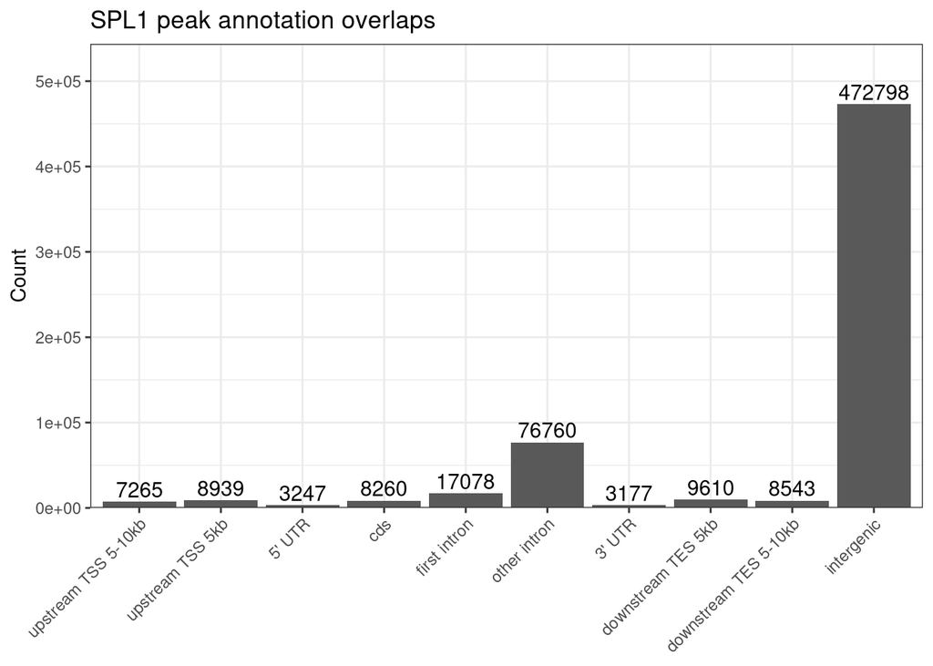

```r
feature_count_plot
```

## 6.6 Unique gene-feature overlap plot

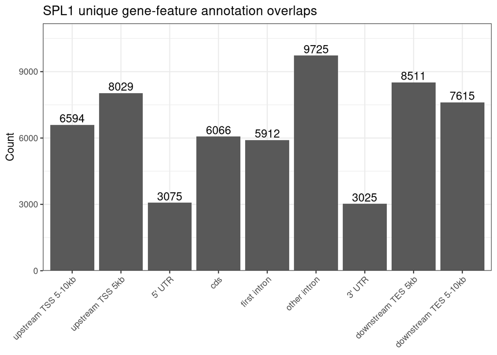

```r
unique_feature_count_plot
```

## 6.7 Unique genes in selected promoter-region combinations plot

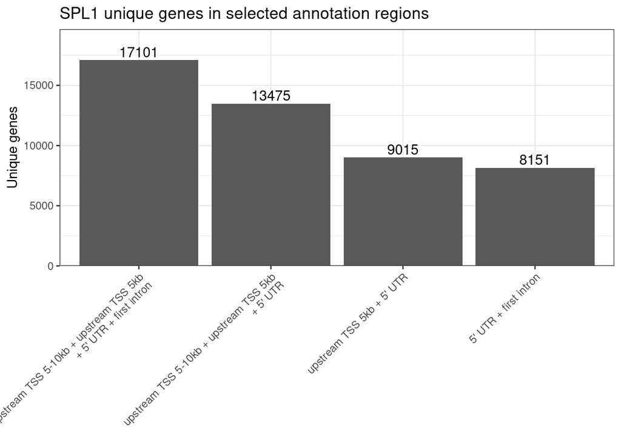

```r
selected_feature_union_plot
```

## 6.8 DE-only test: positive DE genes and SPL1 peak overlap

```r
positive_de_enrichment_matrix
```

```
##                   positive_de
## selected_peak_gene TRUE FALSE
##              TRUE    66    47
##              FALSE  187   157
```

```r
positive_de_enrichment_test
```

```
##
##  Fisher's Exact Test for Count Data
##
## data:  positive_de_enrichment_matrix
## p-value = 0.261
## alternative hypothesis: true odds ratio is greater than 1
## 95 percent confidence interval:
##  0.8039293       Inf
## sample estimates:
## odds ratio
##   1.178549
```

```r
positive_de_enrichment_summary
```

```
##                                                        test
## 1 positive DE genes enriched for SPL1 peaks within DE genes
##              background total_background_genes selected_peak_genes
## 1 all genes in DE sheet                    457                 113
##   positive_de_genes selected_positive_de_genes odds_ratio   p_value
## 1               253                         66   1.178549 0.2609732
```

## 6.9 DE-only test: negative DE genes and SPL1 peak overlap

```r
negative_de_enrichment_matrix
```

```
##                   negative_de
## selected_peak_gene TRUE FALSE
##              TRUE    48    65
##              FALSE  160   184
```

```r
negative_de_enrichment_test
```

```
##
##  Fisher's Exact Test for Count Data
##
## data:  negative_de_enrichment_matrix
## p-value = 0.8038
## alternative hypothesis: true odds ratio is greater than 1
## 95 percent confidence interval:
##  0.5783039       Inf
## sample estimates:
## odds ratio
##  0.8495348
```

```r
negative_de_enrichment_summary
```

```
##                                                        test
## 1 negative DE genes enriched for SPL1 peaks within DE genes
##              background total_background_genes selected_peak_genes
## 1 all genes in DE sheet                    457                 113
##   negative_de_genes selected_negative_de_genes odds_ratio   p_value
## 1               208                         48  0.8495348 0.8038271
```

## 6.10 Expressed-gene background test: DE genes and SPL1 peak overlap

```r
de_expressed_enrichment_matrix
```

```
##                   de_gene
## selected_peak_gene  TRUE FALSE
##              TRUE    113  3800
##              FALSE   344 12026
```

```r
de_expressed_enrichment_test
```

```
##
##  Fisher's Exact Test for Count Data
##
## data:  de_expressed_enrichment_matrix
## p-value = 0.38
## alternative hypothesis: true odds ratio is greater than 1
## 95 percent confidence interval:
##  0.8606345       Inf
## sample estimates:
## odds ratio
##   1.039579
```

```r
de_expressed_enrichment_summary
```

```
##                                                                 test
## 1 DE genes enriched for SPL1 peaks against expressed-gene background
##        background total_background_genes selected_peak_genes de_genes
## 1 expressed genes                  16283                3913      457
##   selected_de_genes odds_ratio   p_value
## 1               113   1.039579 0.3799761
```

# 7 Write to file

Selected promoter peak genes including 5-10 kb upstream TSS for DE output table for further analysis not done in significance testing of overlap with DE genes.

```r
de_output_peak_gene_features <- clean_annotation_intersect %>%
  filter(feature_type %in% c("upstream TSS 5kb", "upstream TSS 5-10kb", "5' UTR")) %>%
  filter(!is.na(gene_id)) %>%
  distinct(gene_id, feature_type) %>%
  group_by(gene_id) %>%
  summarise(
    has_upstream_tss_5kb_peak = any(feature_type == "upstream TSS 5kb"),
    has_upstream_tss_5to10kb_peak = any(feature_type == "upstream TSS 5-10kb"),
    has_5utr_peak = any(feature_type == "5' UTR"),
    selected_peak_feature = paste(
      c(
        if (any(feature_type == "upstream TSS 5kb")) "upstream TSS 5kb",
        if (any(feature_type == "upstream TSS 5-10kb")) "upstream TSS 5-10kb",
        if (any(feature_type == "5' UTR")) "5' UTR"
      ),
      collapse = " + "
    ),
    .groups = "drop"
  )

positive_de_genes_with_selected_peak_ids <- de_table %>%
  filter(Avg..log2FC > 0) %>%
  filter(!is.na(gene_id)) %>%
  inner_join(
    de_output_peak_gene_features,
    by = "gene_id"
  ) %>%
  select(
    Gene.ID,
    gene_id,
    Avg..log2FC,
    has_upstream_tss_5to10kb_peak,
    has_upstream_tss_5kb_peak,
    has_5utr_peak
  ) %>%
  arrange(desc(Avg..log2FC))

negative_de_genes_with_selected_peak_ids <- de_table %>%
  filter(Avg..log2FC < 0) %>%
  filter(!is.na(gene_id)) %>%
  inner_join(
    de_output_peak_gene_features,
    by = "gene_id"
  ) %>%
  select(
    Gene.ID,
    gene_id,
    Avg..log2FC,
    has_upstream_tss_5to10kb_peak,
    has_upstream_tss_5kb_peak,
    has_5utr_peak
  ) %>%
  arrange(Avg..log2FC)

write.table(
  positive_de_genes_with_selected_peak_ids,
  file = here("/mnt/picea/home/tkalman/SPL1_positive_de_genes_with_peak_annotation.tsv"),
  quote = FALSE,
  col.names = c("V1_ID", "V2_ID", "Avg..log2FC", "has_upstream_tss_5to10kb_peak", "has_upstream_tss_5kb_peak", "has_5utr_peak"),
  row.names = FALSE,
  sep = "\t"
)

write.table(
  negative_de_genes_with_selected_peak_ids,
  file = "/mnt/picea/home/tkalman/SPL1_negative_de_genes_with_peak_annotation.tsv",
  quote = FALSE,
  col.names = c("V1_ID", "V2_ID", "Avg..log2FC", "has_upstream_tss_5to10kb_peak", "has_upstream_tss_5kb_peak", "has_5utr_peak"),
  row.names = FALSE,
  sep = "\t"
)
```